# Reproducible Research - Project 1

Guynemer Cétoute

2025-02-21

This doocument is to show the acquired skills from the course Reproducible Research from the R Data Science hosted by Johns Hopkins University from Coursera.

## The steps to load the Data

```r
library(tidyverse)
activity <- read_csv("Downloads/repdata_data_activity/activity.csv")
View(activity)
```

## Question 1: Calculate the total number of steps taken per day

Before showing the total number of steps per day, let us create a new column to assign the name of the day.

```r
activity$days <- wday(activity$date, label = T)
```

```r
activity %>% filter(!is.na(steps)) %>% group_by(days) %>% summarise(Total = sum(steps))
```

```
## # A tibble: 7 × 2
##   days  Total
##   <ord> <dbl>
## 1 Sun   85944
## 2 Mon   69824
## 3 Tue   80546
## 4 Wed   94326
## 5 Thu   65702
## 6 Fri   86518
## 7 Sat   87748
```

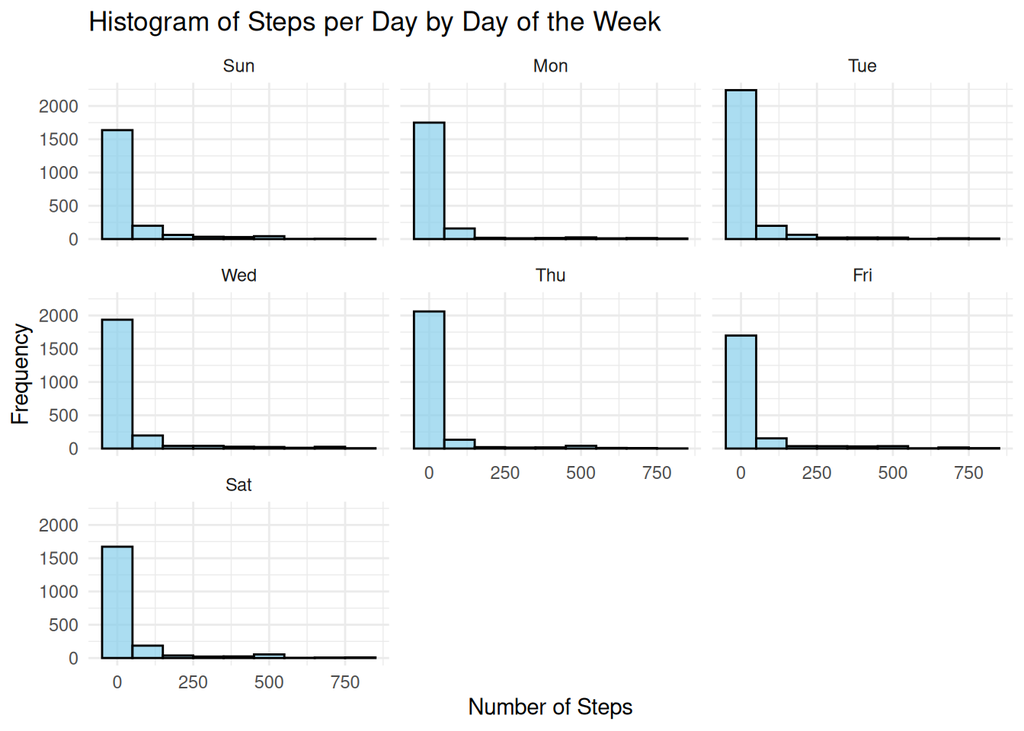

```r
ggplot(activity %>% filter(!is.na(steps)), aes(x = steps)) +
    geom_histogram(binwidth = 100, fill = "skyblue", color = "black", alpha = 0.7) +
    facet_wrap(~ days) + labs(title = "Histogram of Steps per Day by Day of the Week",
         x = "Number of Steps", y = "Frequency") + theme_minimal()
```

## Question 3: Mean and median number of steps taken each day

### To show the number of NA in the column steps

```r
activity %>% filter(is.na(steps)) %>% nrow()
```

```
## [1] 2304
```

### The Means number of steps per day

```r
activity %>% filter(!is.na(steps)) %>% group_by(days) %>% summarise(Average = mean(steps))
```

```
## # A tibble: 7 × 2
##   days  Average
##   <ord>   <dbl>
## 1 Sun      42.6
## 2 Mon      34.6
## 3 Tue      31.1
## 4 Wed      40.9
## 5 Thu      28.5
## 6 Fri      42.9
## 7 Sat      43.5
```

### The Median number of steps per day

```r
activity %>% filter(!is.na(steps)) %>% group_by(days) %>% summarise(Median = median(steps))
```

```
## # A tibble: 7 × 2
##   days  Median
##   <ord>  <dbl>
## 1 Sun        0
## 2 Mon        0
## 3 Tue        0
## 4 Wed        0
## 5 Thu        0
## 6 Fri        0
## 7 Sat        0
```

## Question 4: Time series plot of the average number of steps taken

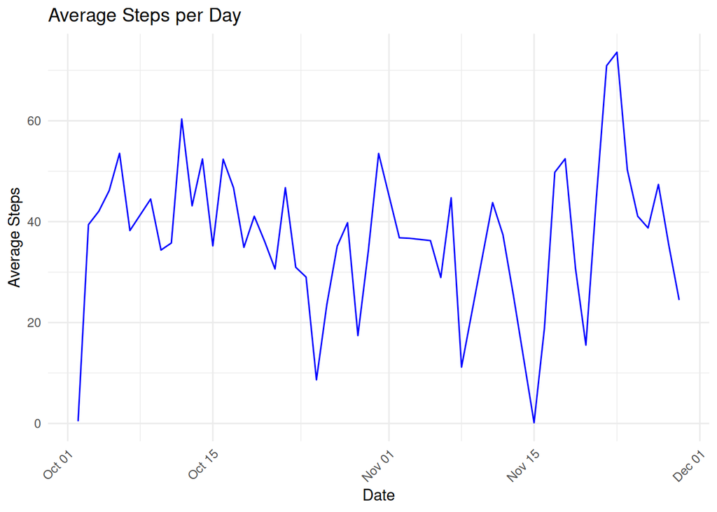

```r
activity %>% filter(!is.na(steps)) %>% group_by(date) %>%
    summarise(avg_steps = mean(steps)) %>%
    ggplot(aes(x = date, y = avg_steps)) + geom_line(color = "blue") +
    labs(title = "Average Steps per Day", x = "Date", y = "Average Steps") +
    theme_minimal() + theme(axis.text.x = element_text(angle = 45, hjust = 1))
```

## Question 5: Code to describe and show a strategy for imputing missing data

Here, I impute the missing data in the steps column by the mean of the column.

```r
activity_2 <- activity %>% mutate(steps = ifelse(is.na(steps),
                                                 mean(steps, na.rm = T), steps))
```

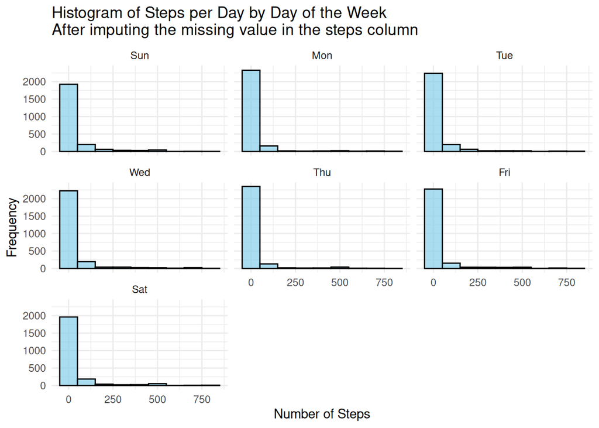

```r
ggplot(activity_2, aes(x = steps)) +
     geom_histogram(binwidth = 100, fill = "skyblue", color = "black", alpha = 0.7) +
     facet_wrap(~ days) +
     labs(title = "Histogram of Steps per Day by Day of the Week \nAfter imputing the missing value in the steps column", x = "Number of Steps", y = "Frequency") +
    theme_minimal()
```

## Question 7: Panel plot comparing the average number of steps taken per 5-minute interval across weekdays and weekends

Before plotting the the graph comparing weekdays with weekends, I have to create another column to separate the weekdays from the weekends.

```r
activity_2$daysType <- case_when(activity_2$days %in%
                                     c('Mon', 'Tue', 'Wed', 'Thu', 'Fri') ~ 'weekday',
                                 activity_2$days %in% c('Sat', 'Sun') ~ 'weekend')
```

Now, this is the plot.

```r
activity_summary <- activity_2 %>%
     group_by(interval, daysType) %>%
     summarise(avg_steps = mean(steps, na.rm = TRUE))
```

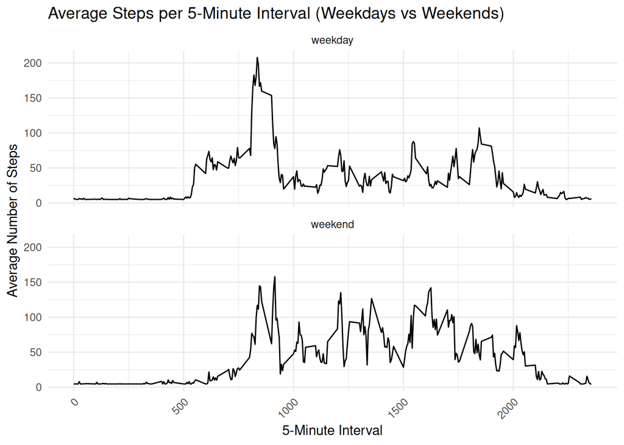

```r
ggplot(activity_summary, aes(x = interval, y = avg_steps)) +
     geom_line() +
     facet_wrap(~ daysType, ncol = 1) +
     labs(title = "Average Steps per 5-Minute Interval (Weekdays vs Weekends)",
                       x = "5-Minute Interval", y = "Average Number of Steps") +
     theme_minimal() +
     theme(axis.text.x = element_text(angle = 45, hjust = 1))
```